# Analiza danych pasażerów Titanica

[figure not shown]

## Cel analizy

### Które cechy pasażerów — płeć, klasa biletu, wiek i port wejścia na pokład — były najsilniej związane z przeżyciem katastrofy?

Zbiór danych zawiera informacje o pasażerach RMS Titanic, który zatonął 15 kwietnia 1912 roku po zderzeniu z górą lodową. Dane obejmują takie atrybuty jak klasa podróży, wiek, płeć, liczba rodzeństwa/małżonków na pokładzie, liczba rodziców/dzieci na pokładzie, cena biletu oraz miejsce zaokrętowania.

Zbiór zawiera także informację o tym, czy pasażer przeżył katastrofę.

Titanic przewoził ponad 2,200 osób, z czego ponad 1,500 zginęło, co czyni tę katastrofę jedną z najbardziej tragicznych w historii morskiej.

Kolumny:

- **pclass** - Klasa biletu
- **survived** - Czy pasażer przeżył katastrofę
- **name** - Imię i nazwisko pasażera
- **sex** - Płeć pasażera
- **age** - Wiek pasażera
- **sibsp** - Liczba rodzeństwa/małżonków na pokładzie
- **parch** - Liczba rodziców/dzieci na pokładzie
- **ticket** - Numer biletu
- **fare** - Cena biletu
- **cabin** - Numer kabiny
- **embarked** - Port, w którym pasażer wszedł na pokład (C = Cherbourg, Q = Queenstown, S = Southampton)
- **boat** - Numer łodzi ratunkowej
- **body** - Numer ciała (jeśli pasażer nie przeżył i ciało zostało odnalezione)
- **home.dest** - Miejsce docelowe

|  | pclass | survived | name | sex | age | sibsp | parch | ticket | fare | cabin | embarked | boat | body | home.dest |
| --- | --- | --- | --- | --- | --- | --- | --- | --- | --- | --- | --- | --- | --- | --- |
| 499 | 2.0 | 0.0 | McCrie, Mr. James Matthew | male | 30.0 | 0.0 | 0.0 | 233478 | 13.0000 | NaN | S | NaN | NaN | Sarnia, ON |
| 513 | 2.0 | 1.0 | Nasser, Mrs. Nicholas (Adele Achem) | female | 14.0 | 1.0 | 0.0 | 237736 | 30.0708 | NaN | C | NaN | NaN | New York, NY |
| 832 | 3.0 | 0.0 | Goodwin, Mrs. Frederick (Augusta Tyler) | female | 43.0 | 1.0 | 6.0 | CA 2144 | 46.9000 | NaN | S | NaN | NaN | Wiltshire, England Niagara Falls, NY |
| 637 | 3.0 | 0.0 | Aronsson, Mr. Ernst Axel Algot | male | 24.0 | 0.0 | 0.0 | 349911 | 7.7750 | NaN | S | NaN | NaN | Sweden Joliet, IL |
| 170 | 1.0 | 1.0 | Ismay, Mr. Joseph Bruce | male | 49.0 | 0.0 | 0.0 | 112058 | 0.0000 | B52 B54 B56 | S | C | NaN | Liverpool |

Zbiór zawiera **1309 rekordów** oraz **14 kolumn**.

Dane obejmują **2 płcie**, **3 klasy biletów**

oraz informację, czy pasażer przeżył katastrofę.

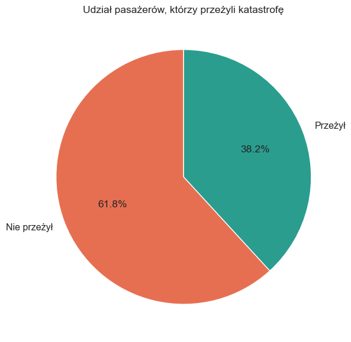

## Krok 1: Ogólny przegląd danych

[figure not shown]

```
<class 'pandas.core.frame.DataFrame'>
Int64Index: 1309 entries, 0 to 1308
Data columns (total 14 columns):
 #   Column     Non-Null Count  Dtype
---  ------     --------------  -----
 0   pclass     1309 non-null   float64
 1   survived   1309 non-null   float64
 2   name       1309 non-null   object
 3   sex        1309 non-null   object
 4   age        1046 non-null   float64
 5   sibsp      1309 non-null   float64
 6   parch      1309 non-null   float64
 7   ticket     1309 non-null   object
 8   fare       1308 non-null   float64
 9   cabin      295 non-null    object
 10  embarked   1307 non-null   object
 11  boat       486 non-null    object
 12  body       121 non-null    float64
 13  home.dest  745 non-null    object
dtypes: float64(7), object(7)
memory usage: 153.4+ KB
```

```
pclass          3
survived        2
name         1307
sex             2
age            98
sibsp           7
parch           8
ticket        929
fare          281
cabin         186
embarked        3
boat           27
body          121
home.dest     369
dtype: int64
```

```
0
```

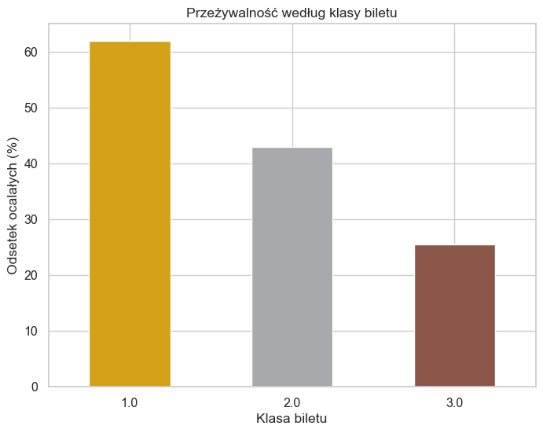

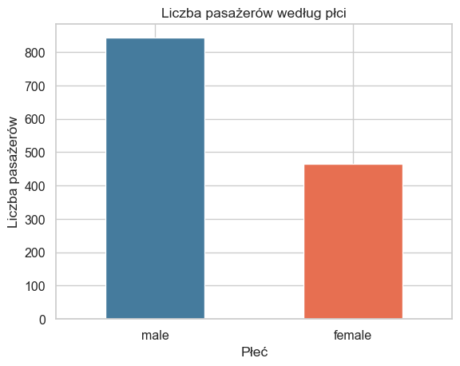

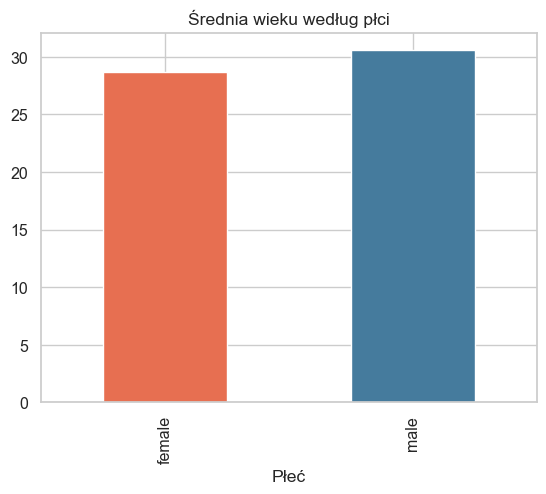

|  | pclass | survived | name | sex | age | sibsp | parch | ticket | fare | cabin | embarked | boat | body | home.dest |
| --- | --- | --- | --- | --- | --- | --- | --- | --- | --- | --- | --- | --- | --- | --- |
| 0 | 1.0 | yes | Allen, Miss. Elisabeth Walton | female | 29.0000 | 0.0 | 0.0 | 24160 | 211.3375 | B5 | S | 2 | NaN | St Louis, MO |
| 1 | 1.0 | yes | Allison, Master. Hudson Trevor | male | 0.9167 | 1.0 | 2.0 | 113781 | 151.5500 | C22 C26 | S | 11 | NaN | Montreal, PQ / Chesterville, ON |
| 2 | 1.0 | no | Allison, Miss. Helen Loraine | female | 2.0000 | 1.0 | 2.0 | 113781 | 151.5500 | C22 C26 | S | NaN | NaN | Montreal, PQ / Chesterville, ON |
| 3 | 1.0 | no | Allison, Mr. Hudson Joshua Creighton | male | 30.0000 | 1.0 | 2.0 | 113781 | 151.5500 | C22 C26 | S | NaN | 135.0 | Montreal, PQ / Chesterville, ON |
| 4 | 1.0 | no | Allison, Mrs. Hudson J C (Bessie Waldo Daniels) | female | 25.0000 | 1.0 | 2.0 | 113781 | 151.5500 | C22 C26 | S | NaN | NaN | Montreal, PQ / Chesterville, ON |

### Spostrzeżenia

- Zbiór zawiera **1309 rekordów i 14 kolumn**.
- Dane dotyczą pasażerów trzech klas biletowych.
- W zbiorze jest **843 mężczyzn** i **466 kobiet**.
- Katastrofę przeżyło **500 osób (38,2%)**, a **809 osób (61,8%)** nie przeżyło.
- Średni wiek pasażerów wynosi około **30 lat**.

## Krok 2: Brakujące wartości

```
body         90.76
cabin        77.46
boat         62.87
home.dest    43.09
age          20.09
embarked      0.15
fare          0.08
dtype: float64
```

```
sex     pclass  survived
male    3.0     no          128
female  3.0     yes          34
                no           30
male    1.0     no           20
        3.0     yes          16
female  1.0     yes          11
male    2.0     no           11
        1.0     yes           8
female  2.0     yes           2
male    2.0     yes           2
female  2.0     no            1
dtype: int64
```

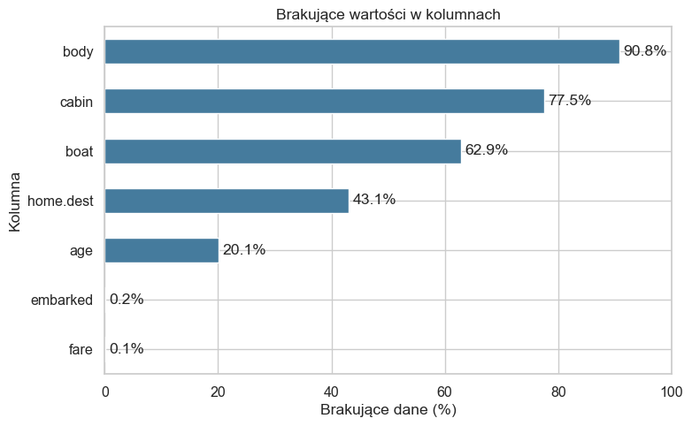

### Spostrzeżenia

- Najwięcej braków występuje w kolumnach `body` (90,8%), `cabin` (77,5%) i `boat` (62,9%).
- Kolumna `age`, ważna dla dalszej analizy, ma braki dla około 20% pasażerów.
- Braki w `fare` i `embarked` są marginalne — po około 0,2%.
- Kolumny `body` oraz `boat` dotyczą zdarzeń po katastrofie, dlatego nie będą używane do analizy czynników związanych z przeżyciem.
- W dalszej części analizy brakujący wiek uzupełnimy medianą obliczoną osobno dla grup płci i klas biletowych.

## Krok 3: Analiza pojedyńczych kolumn:

[figure not shown]

### 1. Przeżywalność

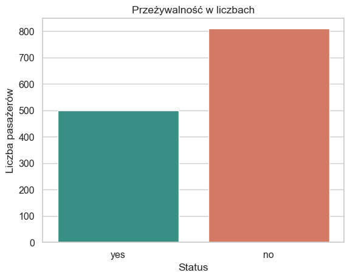

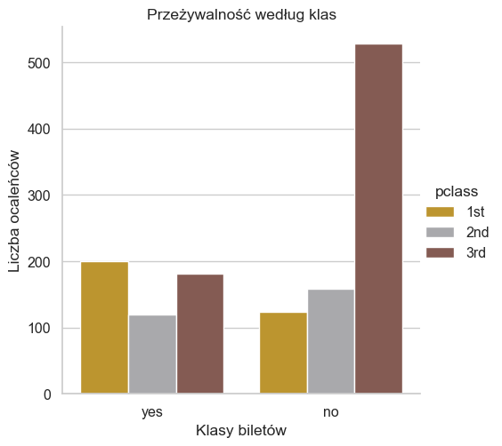

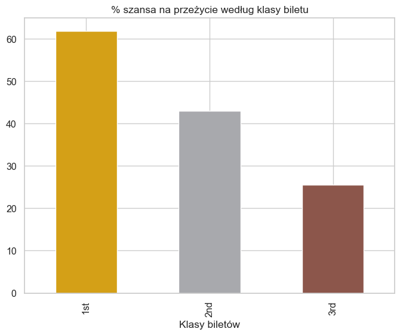

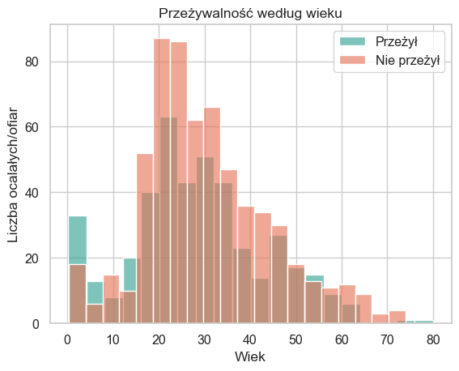

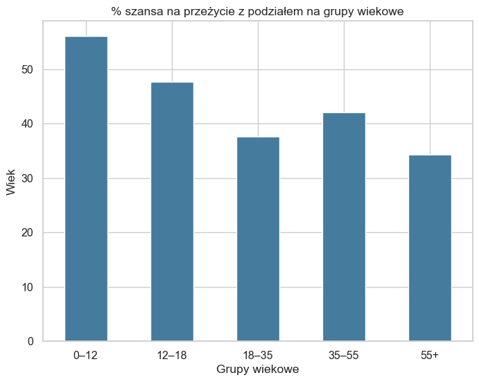

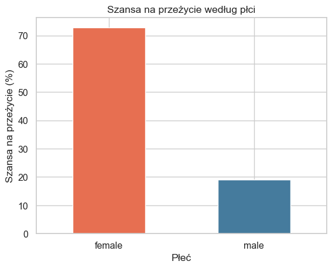

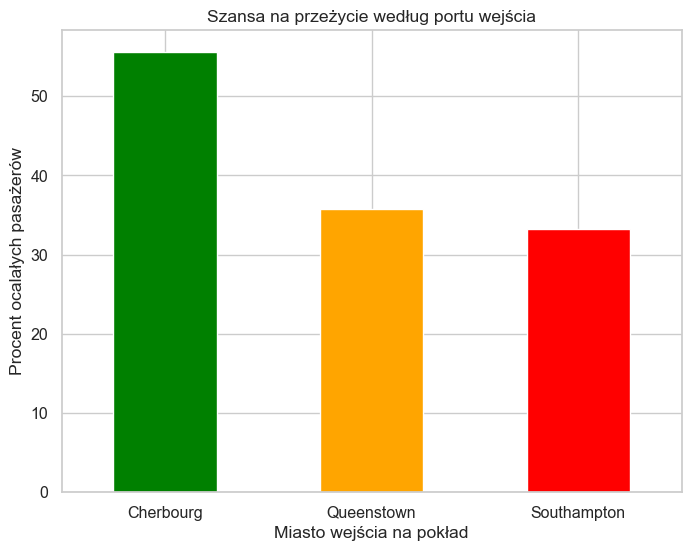

### 2. Podział na klasy

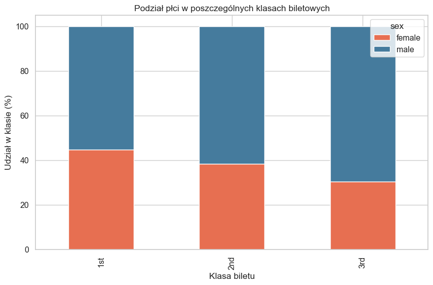

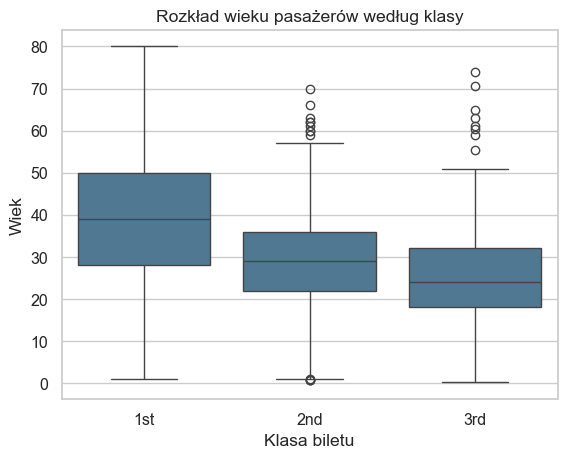

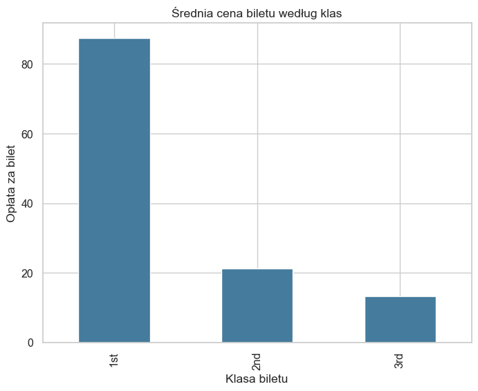

## Ciekawostka historyczna: rozmieszczenie ocalałych w łodziach ratunkowych

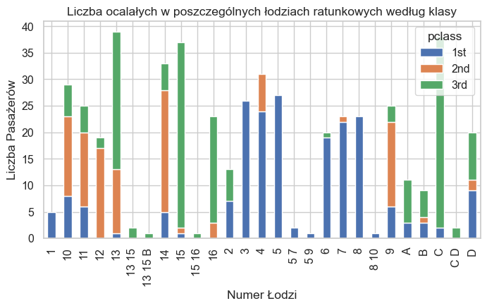

Wykres pokazuje skład pasażerów przypisanych do poszczególnych łodzi ratunkowych. Jest to analiza uzupełniająca — numer łodzi był znany dopiero po katastrofie, dlatego nie używamy go do oceny czynników wpływających na przeżycie.

### Przeżywalność

- Katastrofę przeżyło 38,2% pasażerów.
- Najwyższą przeżywalność odnotowano w klasie pierwszej (61,9%), a najniższą w klasie trzeciej (25,5%).
- Kobiety przeżywały zdecydowanie częściej niż mężczyźni.
- Najwyższy odsetek ocalałych wystąpił wśród dzieci do 12 lat (56,0%).
- Wśród portów wejścia na pokład najwyższą przeżywalność mieli pasażerowie z Cherbourga (55,6%). Ten wynik może być częściowo związany z innym składem pasażerów, np. większym udziałem osób z pierwszej klasy.

### Podział na klasy

- We wszystkich klasach mężczyźni stanowili większość; największy ich udział wystąpił w klasie trzeciej (69,5%).
- Pasażerowie pierwszej klasy byli przeciętnie starsi niż pasażerowie klas drugiej i trzeciej.
- Średnia cena biletu malała wraz z klasą: 87,5 w klasie pierwszej, 21,2 w drugiej i 13,3 w trzeciej.

## Krok 4: Trasformacje

```
Liczba brakujących wartości w kolumnie age: 0
```

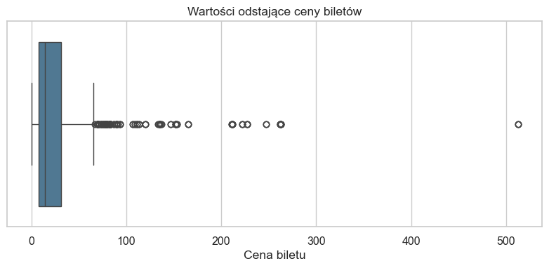

```
Liczba wykrytych wartości odstających: 171
```

```
Low            337
Medium-High    328
High           323
Medium-Low     320
Name: fare_class, dtype: int64
```

| survived fare_class | no | yes |
| --- | --- | --- |
| Low | 77.2 | 22.8 |
| Medium-Low | 71.6 | 28.4 |
| Medium-High | 56.4 | 43.6 |
| High | 41.5 | 58.5 |

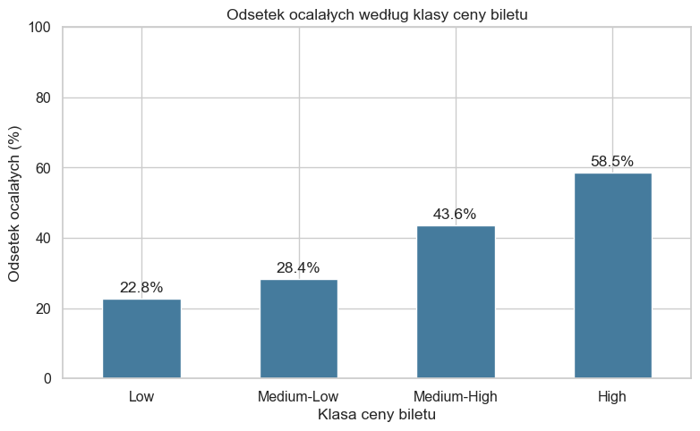

## Krok 5: Relacje

|  | pclass | survived | name | sex | age | sibsp | parch | ticket | fare | cabin | embarked | boat | body | home.dest | age_gap | age_missing | fare_outlier | fare_class |
| --- | --- | --- | --- | --- | --- | --- | --- | --- | --- | --- | --- | --- | --- | --- | --- | --- | --- | --- |
| 224 | 1 | 0 | Partner, Mr. Austen | 0 | 45.5 | 0.0 | 0.0 | 113043 | 28.5000 | C124 | Southampton | NaN | 166.0 | Surbiton Hill, Surrey | 35–55 | False | False | Medium-High |
| 1259 | 3 | 0 | Turcin, Mr. Stjepan | 0 | 36.0 | 0.0 | 0.0 | 349247 | 7.8958 | NaN | Southampton | NaN | NaN | NaN | 35–55 | False | False | Low |
| 930 | 3 | 0 | Kiernan, Mr. Philip | 0 | 25.0 | 1.0 | 0.0 | 367229 | 7.7500 | NaN | Queenstown | NaN | NaN | NaN | NaN | True | False | Low |
| 196 | 1 | 1 | Marechal, Mr. Pierre | 0 | 42.0 | 0.0 | 0.0 | 11774 | 29.7000 | C47 | Cherbourg | 7 | NaN | Paris, France | NaN | True | False | Medium-High |
| 1269 | 3 | 0 | Vande Velde, Mr. Johannes Joseph | 0 | 33.0 | 0.0 | 0.0 | 345780 | 9.5000 | NaN | Southampton | NaN | NaN | NaN | 18–35 | False | False | Medium-Low |

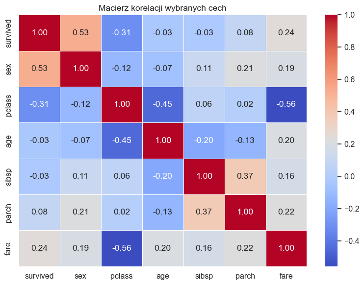

### Spostrzeżenia

- Najsilniejsza zależność występuje między płcią a przeżyciem (`r = 0,53`). Ponieważ `female = 1`, oznacza to, że kobiety częściej przeżywały katastrofę.
- Klasa biletu i cena biletu są umiarkowanie ujemnie skorelowane (`r = -0,56`): niższy numer klasy oznaczał wyższy standard podróży i przeciętnie wyższą cenę biletu.
- Pozostałe zależności są słabe lub umiarkowane.

## Krok 6: Wartości odstające

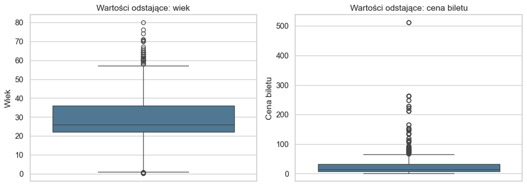

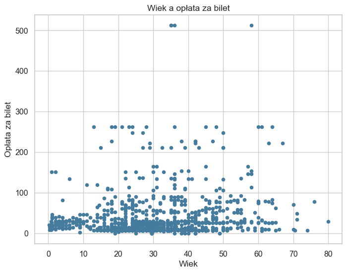

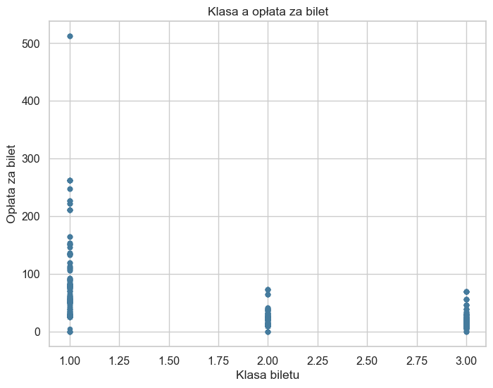

### Spostrzeżenia

- Wiek zawiera pojedyncze wartości odstające, lecz mieszczą się one w realistycznym zakresie od 0 do 80 lat.
- Najwięcej wartości odstających występuje w cenie biletu. Są to przede wszystkim bardzo drogie bilety, głównie w klasie pierwszej.
- Nie usunięto tych obserwacji, ponieważ przedstawiają rzeczywiste różnice w cenie i standardzie podróży.

## Podsumowanie końcowe

[figure not shown]

### 1. Zakres danych i ich jakość

- Analiza obejmuje 1309 pasażerów i 14 pierwotnych kolumn.
- Katastrofę przeżyło 500 osób, czyli 38,2% pasażerów w zbiorze.
- Najwięcej braków dotyczy kolumn `body`, `cabin`, `boat` oraz `home.dest`.
- Brakujące wartości wieku uzupełniono medianą wyznaczoną w grupach płci i klas biletowych.

### 2. Czynniki związane z przeżyciem

- Płeć była najsilniej związana z przeżyciem: korelacja między płcią a przeżyciem wyniosła `r = 0,53`. Kobiety przeżywały znacznie częściej niż mężczyźni.
- Klasa biletu była wyraźnie powiązana z przeżywalnością: w pierwszej klasie przeżyło 61,9% pasażerów, a w trzeciej 25,5%.
- Najwyższy odsetek ocalałych wystąpił wśród dzieci do 12 lat — 56,0%.
- Wśród portów wejścia na pokład najwyższą przeżywalność odnotowano w Cherbourgu — 55,6%. Wynik może być związany z różnym składem pasażerów w portach, np. udziałem osób z pierwszej klasy.

### 3. Klasa podróży i cena biletu

- W każdej klasie było więcej mężczyzn niż kobiet; największy udział mężczyzn wystąpił w klasie trzeciej.
- Pasażerowie pierwszej klasy byli przeciętnie starsi niż pasażerowie klas drugiej i trzeciej.
- Średnia cena biletu wyniosła 87,5 w klasie pierwszej, 21,2 w drugiej i 13,3 w trzeciej.
- Cena biletu i klasa są umiarkowanie ujemnie skorelowane (`r = -0,56`), ponieważ niższy numer klasy oznaczał wyższy standard podróży.
- Przeżywalność rosła wraz z klasą ceny biletu: od 22,8% dla najtańszej grupy do 58,5% dla najdroższej.

### 4. Relacje i wartości odstające

- Poza płcią, klasą biletu i ceną nie występują silne zależności liniowe między analizowanymi cechami.
- Najwięcej wartości odstających występuje w cenie biletu; dotyczą one przede wszystkim bardzo drogich biletów w klasie pierwszej.
- Wartości odstających nie usunięto, ponieważ opisują rzeczywiste różnice w kosztach i standardzie podróży.

### 5. Analiza uzupełniająca: informacje po katastrofie

- Dane o łodziach ratunkowych pokazują skład pasażerów przypisanych do poszczególnych łodzi według klasy podróży.
- Informacja o kabinie jest najczęściej dostępna dla pasażerów pierwszej klasy, lecz kolumna `cabin` zawiera liczne braki.
- Informacja o odnalezieniu ciała również jest niepełna i dotyczy zdarzeń po katastrofie.
- Dane o łodziach, kabinach i ciałach są wartościowe historycznie, ale nie są używane do oceny czynników związanych z przeżyciem, ponieważ opisują skutki katastrofy lub mają znaczną liczbę braków.

### Wniosek

Największe różnice w przeżywalności wiążą się z płcią, klasą biletu, wiekiem oraz ceną biletu. Analiza pokazuje zależności w zbiorze danych, ale sama nie dowodzi bezpośrednich przyczyn przeżycia.

```
0
```

```
0
```